# Computational Statistics 6.1: ANOVA and the F-Test

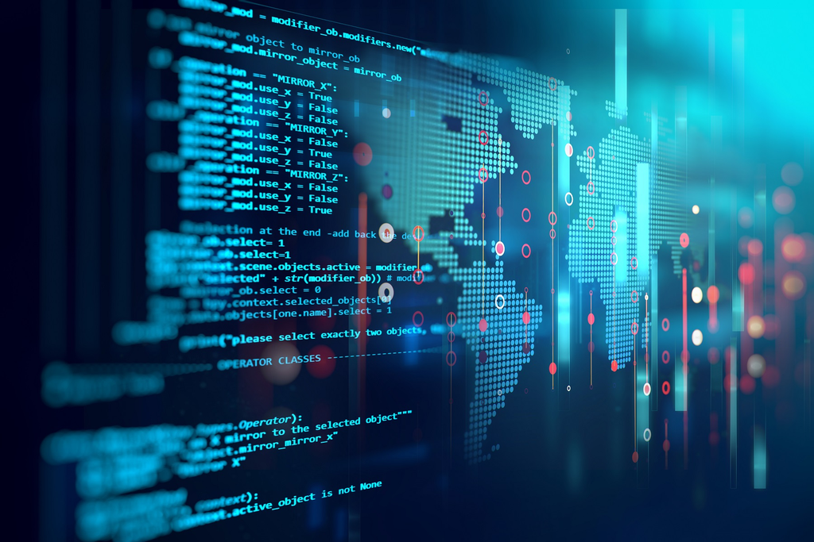

## ANOVA

### Overview

This lesson introduces ANOVA and the F test.

### Objectives

After completing this module, students should be able to:

1. Test for differences among multiple groups.
2. Explain the derivation of the F test.
3. Conduct an F test by hand and using R.

### Readings

Lander, Chapter 18.4. Schumacker, Chapter 14.

## Testing hypothesis with multiple groups

**Previous learing module:**

- **t-test**: Comparing if means of two different groups are statistically different.

**This week:**

- Comparing means for more two or more groups simultaneously.
- For example, in a complex experiment with a number of different treatments, is at least one of them different from the others?
- Do individuals who identify with different political parties (e.g. Republican, Democrat, Independent) think about public matters differently?
- Is the average lifetime earning different among a set of professions (doctor, lawyer, programmer, designer, etc) ?
- Do individuals from different communities have different average life expectancy?

The key difference between the methodology presented in the last learning module and the techniques of this learning module is that now we are generalizing the concept of hypothesis test for instances with more than two groups.

## ANOVA

How do we test for differences in means across multiple groups?

- Through an **Analysis of Variance**, or ANOVA.
- The specific test is called the **F test** and the procedure is very similar to the t test:
1. Formulate hypotheses: $H_0$: All group means are equal. $H_a$: At least one of the means is different.
2. Determine critical rejection region threshold of the test.
3. Calculate the corresponding **F statistic** from the sample (this plays the same role as the **t statistic** in the ANOVA), and compare that to a threshold value which is based on the F distribution - more about the F distribution in the following slides -.
4. Reject the null hypothesis in favor of the alternative hypothesis if the test statistic is in the rejection region (or equivalently, the p-value is less than the significance level).

Why can’t we just use a t test?

### The hypotheses

Assume that we have observations from $g$ different groups, and we want to test if the population mean of each group are statistically different. Formally, we can formulate the following hypothesis:

$H_{0}$ : $\mu_{1} = \mu_{2} = ... = \mu_{g}$

$H_{a}$ : at least one is different.

Where $\mu_{i}$ is the mean of group $i, \forall i = 1,2,...,g$.

### The F statistic

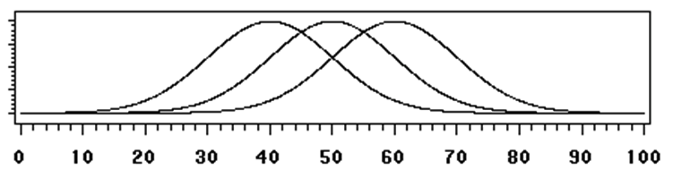

- Each group sample have individual mean and standard deviation.
- The mean of a group may be statistically different from another depending on the spread of each distribution.
- The greater the mean difference among groups, the greater the probability that the samples are drawn from different population distributions.
- But the more spread out each group is, the less different they are likely to be. In other words, the higher the standard deviation - the more disperse is the sample data - the harder it will be for us to statistically proof that the means are different (it will be harder to reject the null hypothesis).

Therefore, we need a ratio as a measure of the total probability that the group means are different:

$$\textrm{F-statistic} = \frac{\textrm{average variance between groups}}{\textrm{average variance within groups}}$$

**The higher the numerator, the more different they are; but the higher the denominator, the less significant that difference is.** This ratio increases when the sample average of the different groups are widely different; but decreases with the dispersion of the data.

### Between-group variance

**What is between-group variance?**

**Conceptually:** The **between group** or **between** variance is an overall measure of how different the means of all the groups are from each other.

**Formally:**

$$\textrm{Between variance } = \frac{n_{1}(\bar{y}_{1} - \bar{y})^{2}+ ... + n_{g}(\bar{y}_{g} - \bar{y})^{2} }{g-1}$$

where $g$ is the number of groups, $n_i$ is the sample size of group $i$, $\bar{y}_i$ is the sample mean of group $i$, and $\bar{y}$ is the overall mean - the mean that result from combining the observations of all samples -.

The between variance can be computed in five simple steps:

1. Calculate the overall mean of the samples pooled together, $\bar{y}$.
2. Then measure how much each group $i$ differs from that overall mean, i.e. compute the difference $\bar{y_i}-\bar{y}$ for each group. And square the previously computed difference.
3. Sum the squared differences. This gives single number that captures the variance of all the $\bar{y}_i$ values around their collective mean $\bar{y}$.
4. Weight each difference, $(\bar{y}_{i} - \bar{y})^{2}$, by the size of the group $n_i$ (because a group of 1000 individuals should have a larger effect on the overall difference between the groups than a group of just 10).
5. Divide by $g-1$. This are the degrees of freedom of the between-group variance. The number of groups $g$ minus one (we substract minus one because we need to use at least one statistic, the pooled sample average, to compute the between-group variance).

The calculation of the between-variance is very similar to a calculation of variance for a single sample, except that we now calculate the group means $\bar{y}_i$ instead of individuals $x_i$, and the $n$ is not the number of individuals, but the number of groups $g$.

### Within-group variance

**What is within-group variance?**

**Formally:**

$$\textrm{Within variance } = \frac{(n_{1}-1)s_{1}^{2}+ ... + (n_{G}-1)s_{g}^{2} }{N-g}$$

where $s_i$ is the standard deviation of group $i$ and $N$ is the overall number of observations (the sum of all $n_{i}$).

This resembles the average variance of all the groups, but again weighted by (approximately) the size of each group:

1. We take the individual variance $s_i^2$ and weight this by the size of the associated group $n_i-1$ (minus 1 for degree-of-freedom reasons). This reflects a greater contribution to the total of bigger groups.
2. Calculate the degrees of freedom: We divide not by $N$ but by $N-g$ for yet another degree-of-freedom reason. Essentially, we have a slightly smaller sample because of the groups, so we subtract the number of groups $g$ from $N$, and divide instead by $N-g$.

### Combining both variances

Now that we know how to compute both the **between-** and **within-** group variance. The **F Statistic** can be computed as:

$$\begin{eqnarray}
\textrm{F-statistic} & = & \dfrac{\textrm{average variance between groups}}{\textrm{average variance within groups}} \\ \\
& = & \dfrac{\dfrac{n_{1}(\bar{y}_{1} - \bar{y})^{2}+ ... + n_{g}(\bar{y}_{g} - \bar{y})^{2} }{g-1}}{\dfrac{(n_{1}-1)s_{1}^{2}+ ... + (n_{G}-1)s_{g}^{2} }{N-g}} \\ \\
& = & \left(\dfrac{N-g}{g-1}\right) \left(\dfrac{n_{1}(\bar{y}_{1} - \bar{y})^{2}+ ... + n_{g}(\bar{y}_{g} - \bar{y})^{2}}{(n_{1}-1)s_{1}^{2}+ ... + (n_{G}-1)s_{g}^{2}}\right) \\ \\
& = & \left(\dfrac{N-g}{g-1}\right) \left(\dfrac{\sum_{i}^{g} n_{i}(\bar{y}_{i} - \bar{y})^{2}}{\sum_{i}^g (n_{i}-1)s_{i}^{2}}\right) \\ \\
\end{eqnarray}$$

There are two degrees of freedom expressions in thge **F statistic**:

- **Degrees of freedom of the numerator**: $g-1$.
- **Degrees of freedom of the denominator**: $N-g$.

When computing the F-statistic threshold in `R` you need to specify each degrees of freedom separately.

## Example 1: Party ID and Ideology

**Research Question:** On an ideology scale (Liberal vs Conservative), does the average ideology differ for Party ID (Democrat, Independent, or, Republican)?

**Method:** Surveying a few hundred people and asking about their party ID and their ideology on a 7-point scale from strong-liberal to strong-conservative.

The following table shows the number of people in each sub-category:

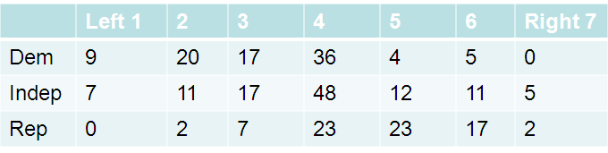

Are the means of each party group (Democrats, Independents, and Republicans) different?

**We need the F test to test whether at least one of the these groups is different from the others.**

### Calculating the F statistic

**F-statistic:**

$$\textrm{F-statistic} = \dfrac{\textrm{average variance between groups}}{\textrm{average variance within groups}}$$

### Calculating the F statistics step by step

**F-statistic:**

F-statistic = $\frac{\textrm{average variance between groups}}{\textrm{average variance within groups}}$

*Between-variance:*

With an overall mean $\bar{y} = 3.89$:

$$\begin{eqnarray*}
\textrm{Between variance } & = & \dfrac{n_{1}(\bar{y}_{1} - \bar{y})^{2}+ ... + n_{G}(\bar{y}_{G} - \bar{y})^{2}}{G-1} \\
\textrm{Between variance } & = & \frac{91(3.23-3.89)^{2} + 111(3.90-3.89)^{2} + 74(4.70-3.89)^{2}}{3-1} = 44.1
\end{eqnarray*}$$

*Within-variance:*

$$\begin{eqnarray*}
\textrm{Within variance } & = & \frac{(n_{1}-1)s_{1}^{2}+ ... + (n_{G}-1)s_{G}^{2} }{N-G} \\
\textrm{Within variance } & = & \frac{(91-1)(1.28)^{2} + (111-1)(1.43)^{2} + (74-1)(1.10)^{2}}{276-3} = 1.69
\end{eqnarray*}$$

*F-statistic:*

$$F = 44.1/1.69 = 26.1$$

How do we know if 26.1 is big enough to reject the null?

### Degrees of freedom

Last week, we learned that the t distribution has one parameter (besides the mean and se) that affects its shape, the degree of freedom, which determines how much of the mass of the distribution is in the tails vs in the middle.

**Degrees of freedom in the F distribution:**

Instead of one, there are now two shape parameters, reflecting two different degrees of freedom:

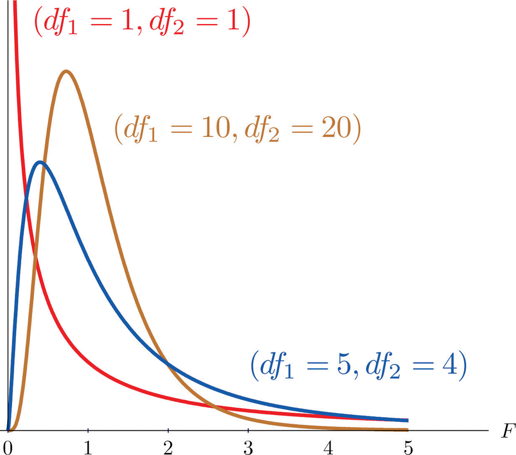

$df_{1} = g-1$ is the denominator on the between variance:

$$\textrm{Between variance } = \frac{n_{1}(\bar{y}_{1} - \bar{y})^{2}+ ... + n_{G}(\bar{y}_{G} - \bar{y})^{2} }{G-1}$$

$df_{2} = N-g$ is the denominator on the within variance:

$$\textrm{Within variance } = \frac{(n_{1}-1)s_{1}^{2}+ ... + (n_{G}-1)s_{G}^{2} }{N-G}$$

$df_{1}$ and $df_{2}$ together determine the shape of the F distribution, and thus whether the F test statistic is large enough to reject the null. In the figure above you can see different representations of the shape of the F distribution as a function of the two degrees of freedom.

### Interpreting the F statistic

- As with the t distribution, we test whether the null hypothesis is true (i.e. whether observed variation between groups is simply due to chance).
- The F distribution defines the probability density function of the ANOVA.
- We want to know if the calculated F statistic is sufficiently unlikely to have been drawn by chance.
- If so, we reject the null, that all the means are the same, in favor of the alternative, that at least one is different from the rest.
- Unlike the t, the F is always non-negative – we are adding non-negative numbers (squared numbers). Thus the F test is always one-tailed.
- To reject the null we need a large F statistic: recall that the formula of the F statistic implies that the more mean difference the larger the F statistic.
- A big F-stat reflects more different means, whereas the smallest number, 0, reflects means that are all identical (the null).
- Then, we’ll reject the null hypothesis if:

$$F_{\text{calculated}} > F_{\text{threshold}}$$

### Calculating the F threshold

Returning to our example, the two degrees of freedom are: $df_{1} = g-1 = 2$ and $df_{2} = N-g = 273$. And the F statistic is $F = 26.1$.

In R, if the significance level $\alpha = 0.05$, then to reject the null we need anF-stat such that area of the distribution greater than the threshold (i.e., the right tail) is 5% of the total.

Thus we can calculate our threshold value as:

```r
#Parameters
N <- 276 # Total number of observations
g <- 3 #Three groups, DEM, REP, IND
alpha <- 0.05 #Significance Level

# Degrees of freedom
df1 <- g - 1 #Degrees of freedom of numerator
df2 <- N - g #Degrees of freedom of denominator

# F threshold
fVal <- qf(1 - alpha, df1, df2) #F value
fVal
```

```
[1] 3.028847
```

The F threshold, `3.03`, is less than the calculated F, 26.1 - well in the rejection region -. This means that we can reject the null that **the means of all three groups are the same, in favor the the alternative hypothesis that at least one of them is different.** . Substantively, the ideology of the different Party ID is different.

### Using p-values

Again as with the t test, we can also calculate directly the p-value for the score we got (26.1), which is the probability of getting something that large or larger assuming the null is true.

```r
1-pf(26.1, df1, df2)
```

```
[1] 4.242806e-11
```

This is clearly much lower that 0.05, so once again we can reject the null.

### Using F tables

More complicated than with the t distribution because now we have three variables, the two degrees of freedom, plus the $\alpha$ level.

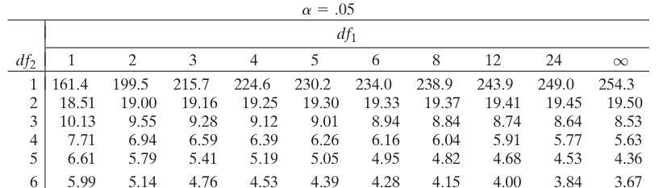

…

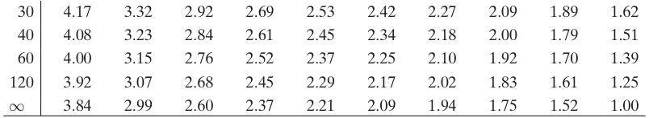

With $df_{1} = 2$ and $df_{2} = 273$, our critical value is around 3, and 26.1 is well above it, so once again we reject the null.

## Doing the F test in R

**Research Question:** We are interested in “alertness” measurements for three different groups, each of which received a different dosage of some drug. Are there any differences in alertness levels across any of these three groups who received different dosages (coded as a, b, and c).

```r
datafilename="http://personality-project.org/r/datasets/R.appendix1.data"
data.ex1=read.table(datafilename,header=T)
head(data.ex1)
```

```
  Dosage Alertness
1      a        30
2      a        38
3      a        35
4      a        41
5      a        27
6      a        24
```

### ANOVA test in R - Example I

```r
aov.ex1 = aov(Alertness~Dosage,data=data.ex1)
summary(aov.ex1)
```

```
            Df Sum Sq Mean Sq F value  Pr(>F)
Dosage       2  426.2  213.12   8.789 0.00298 **
Residuals   15  363.8   24.25
---
Signif. codes:  0 '***' 0.001 '**' 0.01 '*' 0.05 '.' 0.1 ' ' 1
```

The test gives us:

- Degrees of freedom (df_1 =2, there are three groups) and df_2 = 15 (there are 18 observations).
- The between variance (213.12) and the within variance (24.25).
- The F statistic (between variance/within variance) = 8.789.
- The p-value, which equals `1-pf(8.788,2,15)` = 0.00298.

**Bonus:** Although we won’t go into it here, there are also ANOVA equivalents of the dependent-sample test for the t (two-sample) test. But in some ways, the ANOVA has become less common these days, being largely replaced with regression methods, which we will turn to in the next modules. However, the F test underlying ANOVA remains important even in regression, as we will soon see.

### Doing the F test in R with GSS data - Example II

Calculating in R with the GSS data:

From http://gss.norc.org/About-The-GSS: “For more than four decades, the General Social Survey (GSS) has studied the growing complexity of American society. It is the only full-probability, personal-interview survey designed to monitor changes in both social characteristics and attitudes currently being conducted in the United States.” You can download this dataset from *Course Resources > Datasets* in Blackboard.

For this example, we want to know if there is any difference in the attitude towards the future among groups of internet users - categorized by the internet usage time -,

**First**, let’s load the GSS database

```r
setwd("/Users/econphd/Dropbox-NEU/Dropbox/Teaching/NEU/2019/PPUA5301/PPUA5301 - Summer 2019/Lectures/GSS")
gss <- readRDS("GSS2016.Rds")
```

**Second**, for this test are going to extract two variables from the database: (1) `LOTR3` which contains the answers to the survey question *“I’m always optimistic about my future”*, and, (2) `INTWKDYH` which contains the answers to the survey question *“How many minutes or hours do you spend actively using the Internet or web-enabled applications/APPS on a typical weekday?”*. The answers are in a scale of 1-7, any value outside of that range can be considered `NA` in the analysis.

```r
hope <- gss$LOTR3
internetUsage <- gss$intwkdyh
```

**Third**, Cleaning the data

```r
hope <- replace(hope, hope < 1 | hope > 7, NA)
internetUsage <- replace(internetUsage, internetUsage < 1  | internetUsage > 7, NA)

# Converting hope to numeric and internetUsage to factor
hope <- as.numeric(hope)
internetUsage <- as.factor(internetUsage)
```

**Fourth**, Join the two vectors in a data frame and run the ANOVA test

```r
data.ex2 <- data.frame(hope, internetUsage)
aov.ex2 = aov(hope~internetUsage, data=data.ex2)
summary(aov.ex2)
```

```
               Df Sum Sq Mean Sq F value Pr(>F)
internetUsage   6    0.5  0.0880   0.096  0.997
Residuals     702  645.5  0.9195
2158 observations deleted due to missingness
```

The test gives us:

- Degrees of freedom (df_1 = 6, there are 7 groups ) and df_2 = 702 (there are 2,867 observations, but 2,158 contain `NA`. With the 709 that are not `NA`, we can compute df_2 by substracting the number of groups (7)).
- The between variance (0.0880) and the within variance (0.9195).
- The F statistic (between variance/within variance) = 0.096.
- The p-value, which equals `1-pf(0.096,6,702)` = 0.9967652.

Then, at $\alpha = 0.05$, we **cannot reject the null** hypothesis that the average attitude towards the future is equal among groups.